# Best Tennis Players on Different Play Surfaces

## This report takes the results of top mens' tennis players'games and analyzes to see who are the best players on different surfaces i.e. Clay, Grass and Hard Surface.

# Clay Surface

## The graph below shows the winning percentage of the top clay players. As can be seen by the graph below, Rafael Nadal leads this category with a 91% win percentage. Novak Djokovic is not far behind with a 81% win percentage.

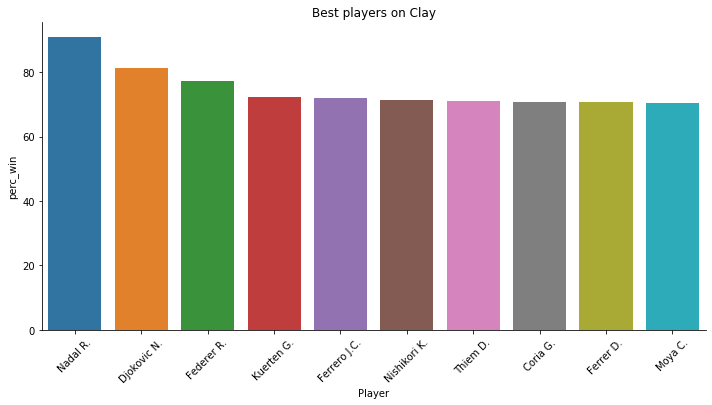

## Another way to represent this data can be shown below. The different colors represent the victories, losess, total play, and percentage winnings of the top players in the 2000's era.

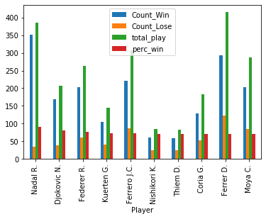

|  | Unnamed: 0 | Surface | Player | Count_Win | Count_Lose | total_play | perc_win |
| --- | --- | --- | --- | --- | --- | --- | --- |
| 0 | 396 | Clay | Nadal R. | 351 | 35 | 386 | 90.93 |
| 1 | 135 | Clay | Djokovic N. | 169 | 39 | 208 | 81.25 |
| 2 | 165 | Clay | Federer R. | 203 | 60 | 263 | 77.19 |
| 3 | 304 | Clay | Kuerten G. | 105 | 40 | 145 | 72.41 |
| 4 | 169 | Clay | Ferrero J.C. | 221 | 86 | 307 | 71.99 |
| 5 | 405 | Clay | Nishikori K. | 60 | 24 | 84 | 71.43 |
| 6 | 550 | Clay | Thiem D. | 59 | 24 | 83 | 71.08 |
| 7 | 100 | Clay | Coria G. | 129 | 53 | 182 | 70.88 |
| 8 | 168 | Clay | Ferrer D. | 293 | 122 | 415 | 70.60 |
| 9 | 389 | Clay | Moya C. | 203 | 85 | 288 | 70.49 |

# Grass Surface

## The graph below shows the winning percentage of the top grass players. As can be seen by the graph below, Roger Federer leads this category with a 88% win percentage. Andy Murray is not far behind with a 83% win percentage.

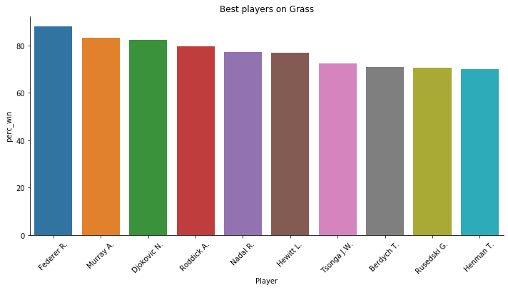

## Another way to represent this data can be shown below. The different colors represent the victories, losess, total play, and percentage winnings of the top players in the 2000's era.

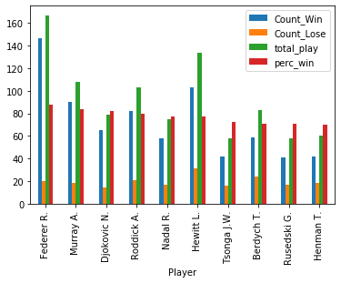

|  | Unnamed: 0 | Surface | Player | Count_Win | Count_Lose | total_play | perc_win |
| --- | --- | --- | --- | --- | --- | --- | --- |
| 0 | 129 | Grass | Federer R. | 147 | 20 | 167 | 88.02 |
| 1 | 289 | Grass | Murray A. | 90 | 18 | 108 | 83.33 |
| 2 | 104 | Grass | Djokovic N. | 65 | 14 | 79 | 82.28 |
| 3 | 345 | Grass | Roddick A. | 82 | 21 | 103 | 79.61 |
| 4 | 291 | Grass | Nadal R. | 58 | 17 | 75 | 77.33 |
| 5 | 182 | Grass | Hewitt L. | 103 | 31 | 134 | 76.87 |
| 6 | 404 | Grass | Tsonga J.W. | 42 | 16 | 58 | 72.41 |
| 7 | 34 | Grass | Berdych T. | 59 | 24 | 83 | 71.08 |
| 8 | 352 | Grass | Rusedski G. | 41 | 17 | 58 | 70.69 |
| 9 | 177 | Grass | Henman T. | 42 | 18 | 60 | 70.00 |

# Hard Surface

## The graph below shows the winning percentage of the top hard surface players. As can be seen by the graph below, Novak Djokovic leads this category with a 85% win percentage. Roger Federer is not far behind with a 83% win percentage.

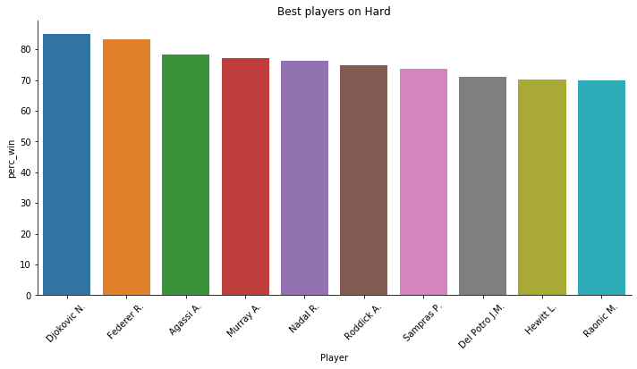

## Another way to represent this data can be shown below. The different colors represent the victories, losess, total play, and percentage winnings of the top players in the 2000's era.

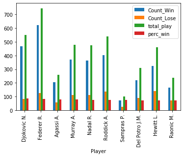

|  | Unnamed: 0 | Surface | Player | Count_Win | Count_Lose | total_play | perc_win |
| --- | --- | --- | --- | --- | --- | --- | --- |
| 0 | 142 | Hard | Djokovic N. | 469 | 82 | 551 | 85.12 |
| 1 | 175 | Hard | Federer R. | 622 | 124 | 746 | 83.38 |
| 2 | 2 | Hard | Agassi A. | 203 | 56 | 259 | 78.38 |
| 3 | 424 | Hard | Murray A. | 369 | 110 | 479 | 77.04 |
| 4 | 426 | Hard | Nadal R. | 363 | 112 | 475 | 76.42 |
| 5 | 509 | Hard | Roddick A. | 402 | 136 | 538 | 74.72 |
| 6 | 531 | Hard | Sampras P. | 73 | 26 | 99 | 73.74 |
| 7 | 129 | Hard | Del Potro J.M. | 220 | 90 | 310 | 70.97 |
| 8 | 257 | Hard | Hewitt L. | 324 | 138 | 462 | 70.13 |
| 9 | 491 | Hard | Raonic M. | 165 | 71 | 236 | 69.92 |